# ChIP-seq data analysis

09/26/2021

# 1 Learning Objectives

- Annotating peaks with gene and genomic feature information
- Obtaining biological context for identified binding sites using functional enrichment tools
- Using the sequence data for peaks to identify possible over-represented motifs

We have identified regions of the genome that are enriched in the number of aligned reads for each of our transcription factors of interest, Nanog and Pou5f1. These enriched regions represent the likely locations of where these proteins bind to the genome. After we obtain a list of peak coordinates, **it is important to study the biological implications of the protein DNA bindings**. Certain questions have always been asked: what are the **genomic annotations and the functions** of these peak regions?

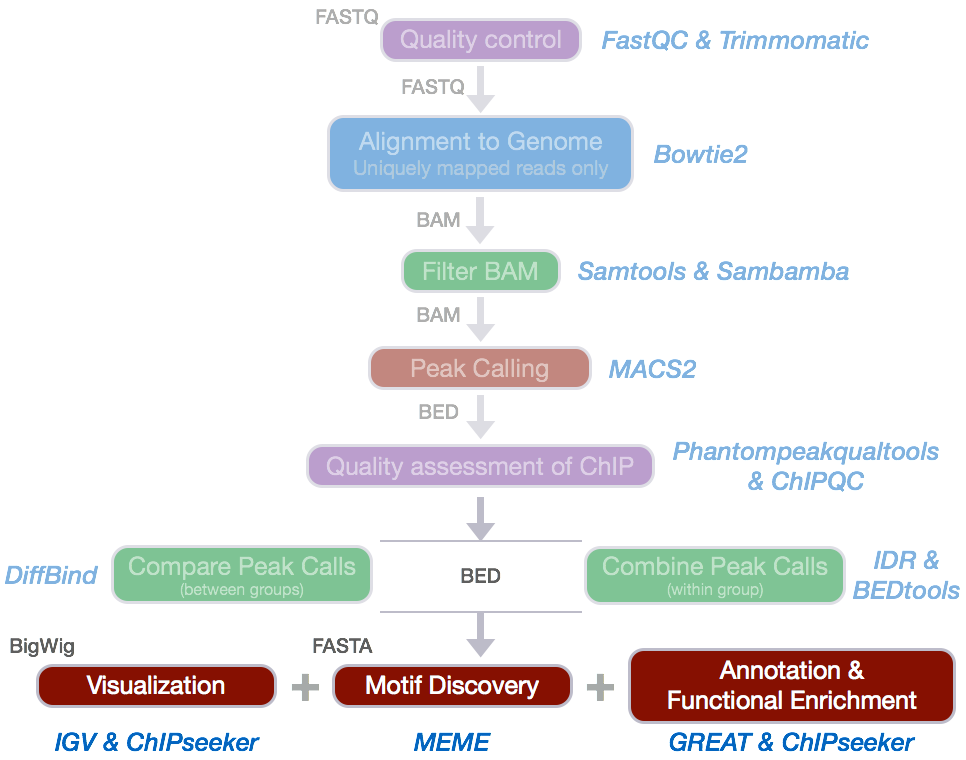

# 2 Peak Annotation

Because many cis-regulatory elements are close to TSSs of their targets, it is common to associate each peak to its nearest gene, either upstream or downstream. [ChIPseeker](http://bioconductor.org/packages/release/bioc/vignettes/ChIPseeker/inst/doc/ChIPseeker.html) is an R Bioconductor package for annotating peaks. Additionally, it has various visualization functions to assess peak coverage over chromosomes and profiles of peaks binding to TSS regions.

## 2.1 Loading data

Peak annotation is generally performed on your high confidence peak calls (after looking at concordance between replicates). While we have a confident peak set for our data, this set is rather small and will not result in anything meaningful in our functional analyses. **We have generated a set of high confidence peak calls using the full dataset.** These were obtained post-IDR analysis, (i.e. concordant peaks between replicates) and are provided in BED format which is optimal input for the ChIPseeker package.

> **NOTE:** the number of peaks in these BED files are are significantly higher than what we observed with the smaller dataset that we have been working with.

```r
# Load data
samplefiles <- list.files("./data/idr-bed", pattern= ".bed", full.names=T)
# samplefiles <- list.files("data/idr-bed", pattern= ".bed", full.names=T)
samplefiles <- as.list(samplefiles)
names(samplefiles) <- c("Nanog", "Pou5f1")
```

Next, we need to **assign annotation databases** generated from UCSC to a variable:

```r
txdb <- TxDb.Hsapiens.UCSC.hg19.knownGene
```

> **NOTE:** *ChIPseeker supports annotating ChIP-seq data of a wide variety of species if they have transcript annotation TxDb object available.* To find out which genomes have the annotation available follow [this link](http://bioconductor.org/packages/3.5/data/annotation/) and scroll down to “TxDb”. Also, if you are interested in creating your own TxDb object you will find [more information here](https://bioconductor.org/packages/devel/bioc/vignettes/GenomicFeatures/inst/doc/GenomicFeatures.pdf).

## 2.2 Annotation

Many annotation tools use nearest gene methods for assigning a peak to a gene in which the algorithm looks for the nearest TSS to the given genomic coordinates and annotates the peak with that gene. This can be misleading as **binding sites might be located between two start sites of different genes**.

The **`annotatePeak` function**, as part of the ChIPseeker package, uses the nearest gene method described above but also **provides parameters to specify a max distance from the TSS.** For annotating genomic regions, `annotatePeak` will not only give the gene information but also reports detail information when genomic region is Exon or Intron. For instance, âExon (uc002sbe.3/9736, exon 69 of 80)’, means that the peak overlaps with the 69th exon of the 80 exons that transcript uc002sbe.3 possess and the corresponding Entrez gene ID is 9736.

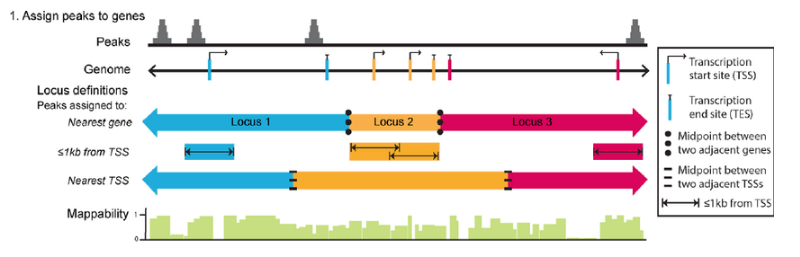

Let’s start by retrieving annotations for our Nanog and Pou5f1 peaks calls:

```r
peakAnnoList <- lapply(
  samplefiles,
  annotatePeak,
  TxDb = txdb,
  tssRegion = c(-1000, 1000),
  verbose = FALSE
)
```

If you take a look at what is stored in `peakAnnoList`, you will see that the peak annotations have been summarized for you based on genomic features:

[output not shown]

ChIPseeker provides several functions to visualize the annotations using various plots. We will demonstrate a few of these using the Nanog sample. We will also show you how some of the functions can support comparing annotation information across samples.

> **NOTE**: ChIPseeker also has functionality to **generate figures for visualization** (similar to what we did in `deepTools`). If you are interested in testing out those functions on this data, please see the [materials linked here](https://hbctraining.github.io/Intro-to-ChIPseq/lessons/chipseeker_visualization.html).

## 2.3 Barchart of genomic feature representation

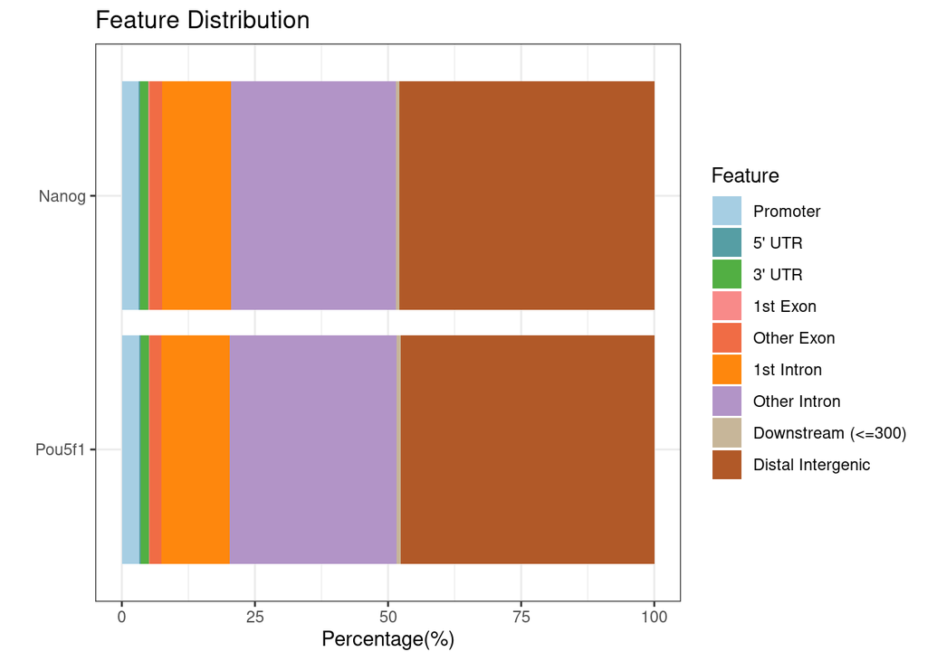

```r
plotAnnoBar(peakAnnoList)
```

## 2.4 Distribution of TF-binding loci relative to TSS

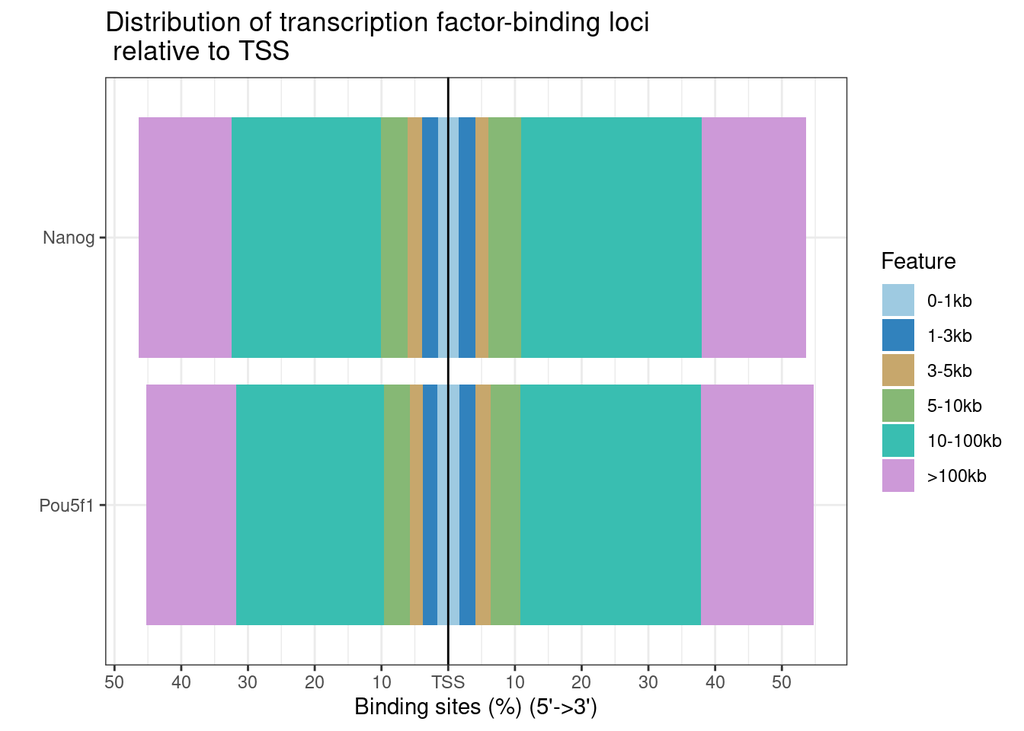

```r
plotDistToTSS(peakAnnoList, title = "Distribution of transcription factor-binding loci \n relative to TSS")
```

Finally, it would be nice to have the **annotations for each peak call written to file**, as it can be useful to browse the data and subset calls of interest. The annotation information is stored in the `peakAnnoList` object. To retrieve it we use the following syntax:

```r
nanog_annot <- data.frame(peakAnnoList[["Nanog"]]@anno)
```

Take a look at this data frame. You should see columns corresponding to your input BED file and additional columns containing nearest gene(s), the distance from peak to the TSS of its nearest gene, genomic feature annotation of the peak and other information. Since some annotations may overlap, ChIPseeker has adopted the following priority in how it lists information:

- Promoter
- 5’ UTR
- 3’ UTR
- Exon
- Intron
- Downstream (defined as the downstream of gene end)
- Intergenic

One thing you will notice is that the gene identifiers that are listed are EntrezIDs. It would be easier to browse through the results if we had gene symbols. We will obtain this information using `AnnotationDbi`, an R package that provides an interface for connecting and querying various annotation databases using SQLite data storage. The AnnotationDbi packages can query the OrgDb, TxDb, EnsDb, Go.db, and BioMart annotations. There is [helpful documentation](https://bioconductor.org/packages/release/bioc/vignettes/AnnotationDbi/inst/doc/IntroToAnnotationPackages.pdf) available to reference when extracting data from any of these databases.

Although we have been using the TxDb database with ChIPseeker, there is limited options as to what other identifiers can be retrieved.

```
keytypes(TxDb.Hsapiens.UCSC.hg19.knownGene)
[1] "CDSID"    "CDSNAME"  "EXONID"   "EXONNAME" "GENEID"   "TXID"     "TXNAME"
```

Since we want to map our EntrezIDs to gene symbols, we will need to use another database. The `EnsDb.Hsapiens.v75` database corresponds to hg19, and so is an appropriate option.

```r
# Get the entrez IDs
entrez <- nanog_annot$geneId

# Return the gene symbol for the set of Entrez IDs
annotations_edb <- AnnotationDbi::select(
  EnsDb.Hsapiens.v75,
  keys = entrez,
  columns = c("GENENAME"),
  keytype = "ENTREZID"
)

# Change IDs to character type to merge
annotations_edb$ENTREZID <- as.character(annotations_edb$ENTREZID)

# Write to file
# nanog_annot %>%
#   left_join(annotations_edb, by=c("geneId"="ENTREZID")) %>%
#   write.table(file="results/Nanog_peak_annotation.txt", sep="\t", quote=F, row.names=F)
```